# Straws-Sample-Confidence-Intervals

Jose Rico

April 13, 2020

# Background

As you have probably surmised by now that statistics from a sample has inherent variability from the randomness in the sampling process. When statisticians take a sample and they want to report the sample statistics as an estimate for the population, they are careful in their reporting. Their trick is to provide an interval where they are confident (to a stated probability) that the true population proportions will lie within the interval.

## Reporting Sampling Statistics with a Confidence Interval

With our understanding of sampling distributions, we can see that is likely that our sample proportion could be a predictable distance from the true population proportion. 95% of our samples should be within approximately two standard deviations from the true population proportion. We use this observation to construct a 95% confidence interval (*which is range that we are 95% confident that the true population proportion will lie in*)

### Sample Distribution’s Standard Deviation

We can predict/calculate the sampling standard deviation for a given a sample size with the following equation;

**Standard Deviation of Sampling Distribution (aka Sampling Error)**

$SE=\sqrt{\frac{p(1-p)}{n}}$

### Margin of Error

From the standard error, we can calculate the margin of error by multiplying the standard error by 2 (since for 95% confidence we need to cover +/- 2 standard deviations, due to the randomness in selecting a single sample - which results in variability of sample proportions from the true population proportion)

An additional option with confidence intervals is choose a confidence level other than 95%. This requires us to modify the formula for margin of error;

**Margin of Error**

$ME=z^*\sqrt{\frac{p(1-p)}{n}}$

where $z^*$ is a z score (from a standardized normal distribution) that correlates with the given confidence level. $z=1.96$ for 95% (we often approximate 1.96 as 2 to simplify mental calculations)

### Construction of the confidence interval

Confidence Intervals have an lower and upper bound that can be calculated by adding and subtracting the margin of error from the sample proportion (aka point estimate)

$\hat{p}\pm ME$

### Constructing the CI in R from a single sample

Note: this is a 95% Confidence Interval, since our $z = qnorm(0.975) = 1.959964$.

You can determine the argument for **qnorm** by taking the average of **1** and the confidence level. (e.g., $\frac{1+0.95}{2}=0.975$)

```r
set.seed(1234567)

n = 400

sample1 <- straws %>%
  sample_n(size = n, replace = F )

stat_sample1 <- sample1 %>%

      summarize(blue = sum(color == "blue"),
                prop_blue = blue/ n,
                se = sqrt(prop_blue*(1-prop_blue)/n),
                me = qnorm(0.975) * se,
                lower = prop_blue - me,
                upper = prop_blue + me)

kable(stat_sample1) %>%
    kable_styling(bootstrap_options = "striped",
                  full_width = F, position = "left")
```

| blue | prop_blue | se | me | lower | upper |
| --- | --- | --- | --- | --- | --- |
| 76 | 0.19 | 0.019615 | 0.0384448 | 0.1515552 | 0.2284448 |

# Let R do all the work

The `mosaic` package has a function **binom.test** that when piped into **confint** function, a confidence interval is constructed from a data frame. The first argument `~(color == "blue")` tells R to construct the interval for the proportion of **color**’s are **blue**. There are a variety of methods to construct confidence intervals, we are using the **Wald Method** which matches the formulas discussed earlier.

```r
### this code requires the mosaic package
binom.test(~(color == "blue"), conf.level = 0.95, ci.method= "Wald", data = sample1) %>%
  confint()
```

```
##   probability of success     lower     upper level
## 1                   0.19 0.1515552 0.2284448  0.95
```

## Confidence Interval without a dataframe.

If you don’t have a data frame, but you know the number of blue straws for a given sample size, you can enter them as arguments to the **binom.test** function. **x** is equal the number of successes (blue straws) and **n** is equal to the size of the sample.

```r
binom.test(x=145, n=970, ci.method= "Wald") %>%
  confint()
```

```
##   probability of success     lower     upper level
## 1              0.1494845 0.1270456 0.1719234  0.95
```

# How good is my Confidence Interval

## Find True Population proportion of blue straws

Normally, a researcher will never know the true population parameters since it is very challenging to obtain data from every member of a population. But, for our scenario with our 2500 virtual straws we can easily find the population’s proportion of blue straws. Since we are able to know the true population parameter, we will be able to evaluate the success of our parameter estimates (i.e., do are confidence intervals capture the true population proportion)

```r
parameters <- straws %>%
          summarize(blue = sum(color == "blue"),
                    prop_blue = blue/ 2500)
parameters
```

```
## # A tibble: 1 x 2
##    blue prop_blue
##   <int>     <dbl>
## 1   476     0.190
```

# Take Muliple Samples

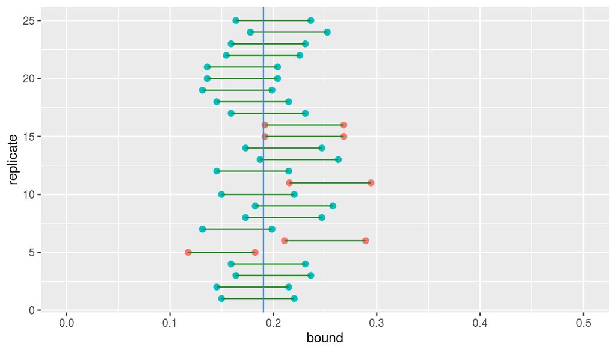

```r
set.seed(1234567)

n1 = 200

samples_n50_reps20 <- straws %>%
        rep_sample_n(size = n1, reps = 25, replace = F)

ci_n50_reps20 <-  samples_n50_reps20 %>%

    group_by(replicate) %>%

          summarize(blue = sum(color == "blue"),
                  prop_blue = blue/ n1,
                  se = sqrt(prop_blue*(1-prop_blue)/n1),  ### need to modify for proper sample size
                  me = qnorm(0.9) * se,
                  lower = prop_blue - me,
                  upper = prop_blue + me)

ci_n50_reps20 <- ci_n50_reps20 %>%
  mutate(capture_p = ifelse(lower < 0.1904 & upper > 0.1904, "yes", "no"))

ci_n50_reps20_data <- gather(ci_n50_reps20, type, bound, lower:upper)

ci_n50_reps20_data %>%

  ggplot(aes(y = replicate, x = bound, group = replicate, color =capture_p)) +
    geom_point(size = 2)+
    geom_line(color="forestgreen")+
    geom_vline(xintercept = 0.1904, color = "steelblue")+
    scale_x_continuous(limits = c(0.00, 0.50))+
    theme(legend.position = "none")
```